# Case Study 2: Heliotronics Estimating an Experience Curve

# 2 Principal Axis Factoring

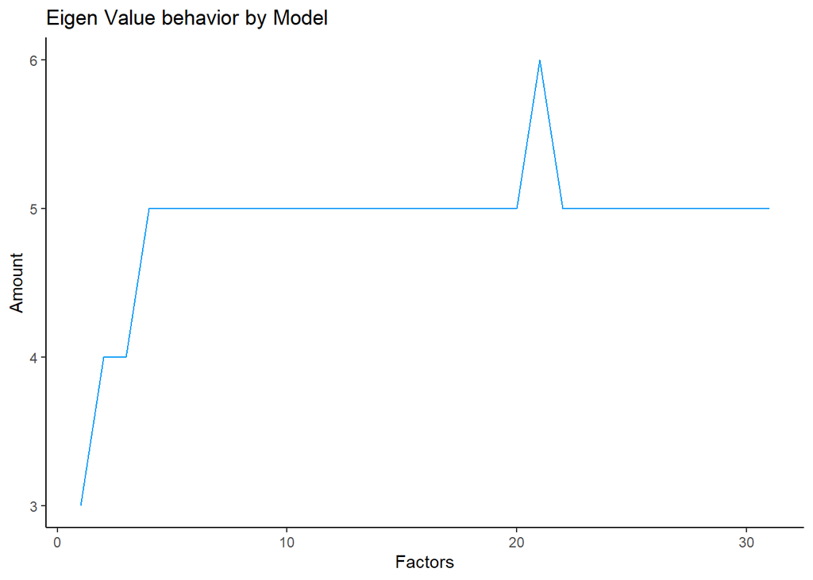

```r
#tried to find the best amount of factors in PAF.
#Always around 5 which is lower than the ideal 8.

#find best combination of factors
best_factors <- data.table("Factors" = double(), "Amount" = double())
best_eigen <- data.table("Index" = 1:31)

for(i in 1:31){
  temp_paf <- psych::fa(data.table(scale(cel_data_quests[,-c(4,23)])), nfactors = i, rotate = "varimax", scores = T)
  fact_len <- length(which(temp_paf$values > 1))
  best_eigen <- best_eigen[,paste("Factor_", i, sep=""):= temp_paf$values]
  best_factors <- rbindlist(list(best_factors,list(i, fact_len)))
}

#plot the amount of factors with eigen value >1 for each nfactors up to 33
ggplot(best_factors, aes(Factors,Amount))+
  geom_line(color = "#0099F8", size = 0.5)+
  ggtitle("Eigen Value behavior by Model")+
  labs(xlab="Model", ylab = "Amount of factors")+
  theme_classic()
```

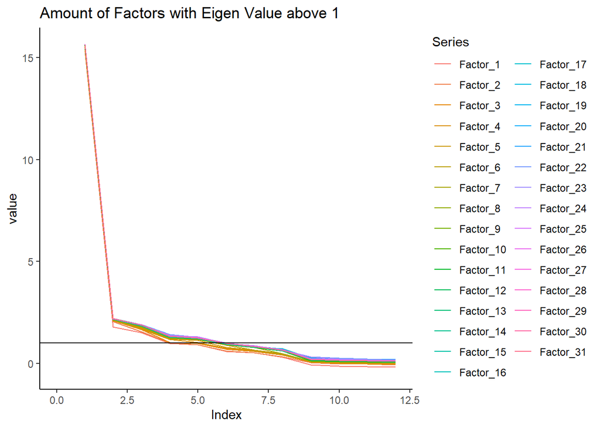

```r
#Plot the behavior of eigen values per amount of factors per model
best_eigen_melt <- melt(best_eigen ,  id.vars = "Index", variable.name = "Series")
ggplot(best_eigen_melt, aes(Index, value))+
  geom_line(aes(color = Series))+
  xlim(0,12)+
  geom_hline(yintercept=1)+
  ggtitle("Amount of Factors with Eigen Value above 1")+
  labs(xlab="Amount of Factors", ylab = "Eigen Value")+
  theme_classic()
```

```r
#calculate the eigen values with best number of factors
paf1 <- psych::fa(cel_data_quests, nfactors = 5, rotate = "Varimax", scores = T)
summary(paf1)
```

```
##
## Factor analysis with Call: psych::fa(r = cel_data_quests, nfactors = 5, rotate = "Varimax",
##     scores = T)
##
## Test of the hypothesis that 5 factors are sufficient.
## The degrees of freedom for the model is 373  and the objective function was  4.48
## The number of observations was  965  with Chi Square =  4250.37  with prob <  0
##
## The root mean square of the residuals (RMSA) is  0.04
## The df corrected root mean square of the residuals is  0.05
##
## Tucker Lewis Index of factoring reliability =  0.816
## RMSEA index =  0.104  and the 10 % confidence intervals are  0.101 0.107
## BIC =  1687.07
```

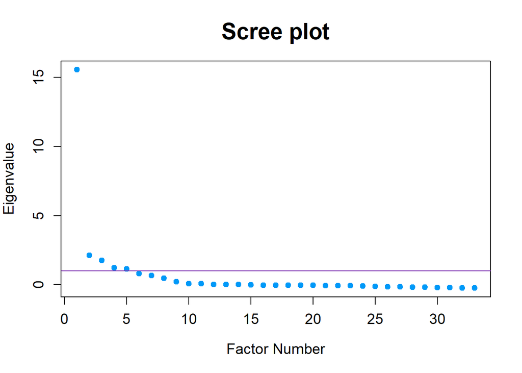

```
## integer(0)
```

```r
#display Scree-plot
plot(paf1$values,
     xlab="Factor Number",
     ylab="Eigenvalue",
     main="Scree plot",
     cex.lab=1.2,
     cex.axis=1.2,
     cex.main=1.8,
     col = "#0099F8",
     pch = 19) +abline(h=1, col = "#7F35B2")
```

```r
#PAF always suggests 5 factors. However based on how they line up it does not make logical sense.
```

```r
#calculate total variance using PAF with nfators = 5
pafEigenValue <- paf1$values
pafVariance <- pafEigenValue / ncol(cel_data_quests) * 100
pafSumVariance <- cumsum(pafEigenValue / ncol(cel_data_quests))
pafTotal_Variance_Explained <- cbind(EigenValue = pafEigenValue[pafEigenValue>0],
                                  Variance = pafVariance[pafEigenValue>0],
                                  Total_Variance = pafSumVariance[pafEigenValue>0])
#display table
pafTotal_Variance_Explained |>
  kable() |>
  kable_minimal()
```

| EigenValue | Variance | Total_Variance |
| --- | --- | --- |
| 15.5454016 | 47.1072775 | 0.4710728 |
| 2.1156113 | 6.4109434 | 0.5351822 |
| 1.7560704 | 5.3214255 | 0.5883965 |
| 1.2117936 | 3.6721019 | 0.6251175 |
| 1.1270395 | 3.4152711 | 0.6592702 |
| 0.7937869 | 2.4054147 | 0.6833243 |
| 0.6548350 | 1.9843485 | 0.7031678 |
| 0.4519077 | 1.3694173 | 0.7168620 |
| 0.2101050 | 0.6366818 | 0.7232288 |
| 0.0807037 | 0.2445567 | 0.7256744 |
| 0.0554299 | 0.1679695 | 0.7273541 |
| 0.0189172 | 0.0573248 | 0.7279273 |
| 0.0124175 | 0.0376289 | 0.7283036 |

```r
#Show lodings for PAF using nfactors = 5
print(paf1$loadings, cutoff=0.4, sort=TRUE)
```

```
##
## Loadings:
##      MR2    MR5    MR3    MR1    MR4
## qd9   0.850
## qd14  0.869
## qd19  0.850
## qd21  0.803
## qd24  0.880
## qd1          0.797
## qd10         0.783
## qd20         0.789
## qd27         0.763
## qd15                0.532
## qd22                0.741
## qd26                0.575
## qd28                0.518
## qd29                0.753
## qd31                0.595
## qd33                0.707
## qd2                        0.662
## qd5                        0.655
## qd6          0.449         0.529
## qd7                        0.698
## qd8                        0.528
## qd12                       0.661
## qd16                       0.604
## qd25         0.417         0.507
## qd3                               0.748
## qd11                              0.754
## qd13                              0.732
## qd30                              0.694
## qd4
## qd17                0.488
## qd18         0.443         0.475
## qd23
## qd32         0.436  0.482
##
##                  MR2   MR5   MR3   MR1   MR4
## SS loadings    5.208 4.608 4.201 4.195 3.545
## Proportion Var 0.158 0.140 0.127 0.127 0.107
## Cumulative Var 0.158 0.297 0.425 0.552 0.659
```

```r
#Talk about groupings not being precise with assignment from groups in the PDF.
#Mention the variables being predicted by multiple variables
#mention the need to improve the groupings
```

As so, the loadings match the questions as follow:

- Questions 2, 5, 6, 7, 8, 12, 16, 18 and 25 are regarding **Performance and Features**
- Questions 9, 14, 19, 21, 24 are regarding **Serviceability**
- Questions 15, 17, 22, 26, 28, 29, 31, 32, 33 are regarding **Durability and Reliability**
- Questions 3, 11, 13, 30 are regarding **Ease of use**
- Questions 1, 10, 20, 27 are regarding **Aesthetics**
- Questions 4 and 23 are not added to any factor

**Click here to detailed groupings**

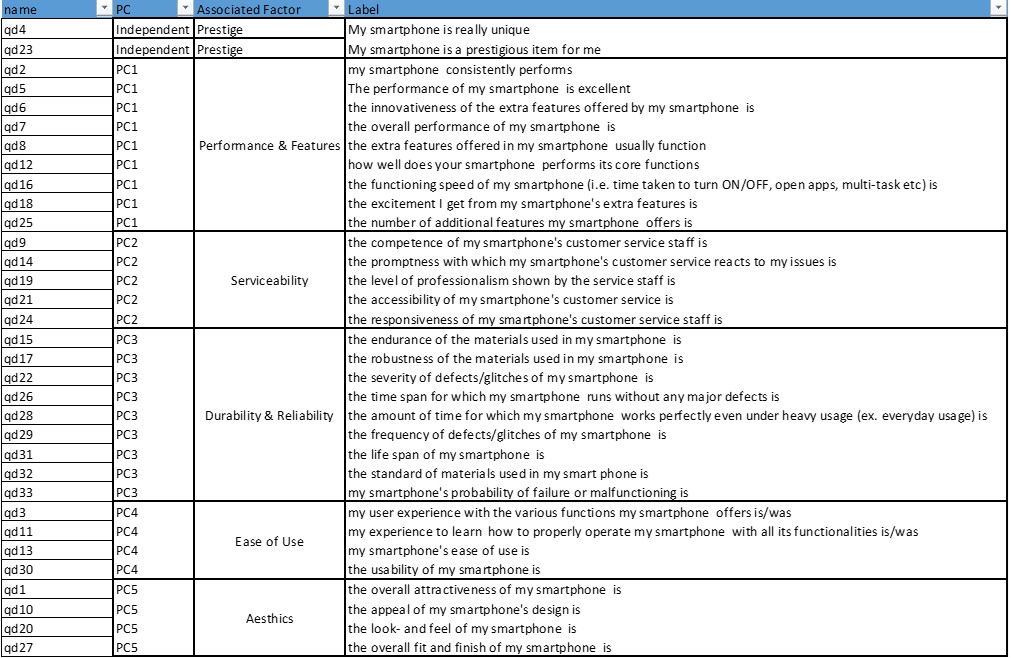

Groupings as per PAF analysis. Source: own creation

# 3 Principal Component Analysis

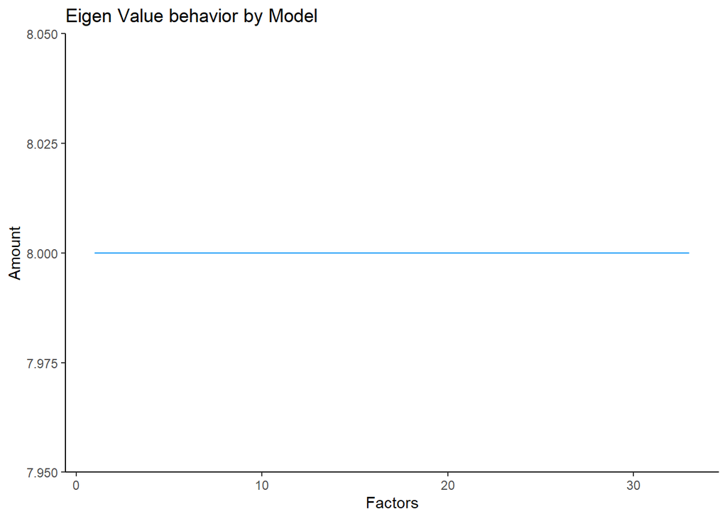

```r
#find best combination of factors
best_factors_pc <- data.table("Factors" = double(), "Amount" = double())
best_eigen_pc <- data.table("Index" = 1:33)

for(i in 1:33){
  temp_paf_pc <- psych::principal(data.table(scale(cel_data_quests)), nfactors = i, rotate = "varimax", scores = T)
  fact_len_pc <- length(which(temp_paf_pc$values > 1))
  best_eigen_pc <- best_eigen_pc[,paste("Factor_", i, sep=""):= temp_paf_pc$values]
  best_factors_pc <- rbindlist(list(best_factors_pc,list(i, fact_len_pc)))
}

#plot the amount of factors with eigen value >1 for each nfactors up to 33
best_factors_plot <- ggplot(best_factors_pc, aes(Factors,Amount))+
  geom_line(color = "#0099F8", size = 0.5)+
  ggtitle("Eigen Value behavior by Model")+
  labs(xlab="Model", ylab = "Amount of factors")+
  theme_classic()
best_factors_plot
```

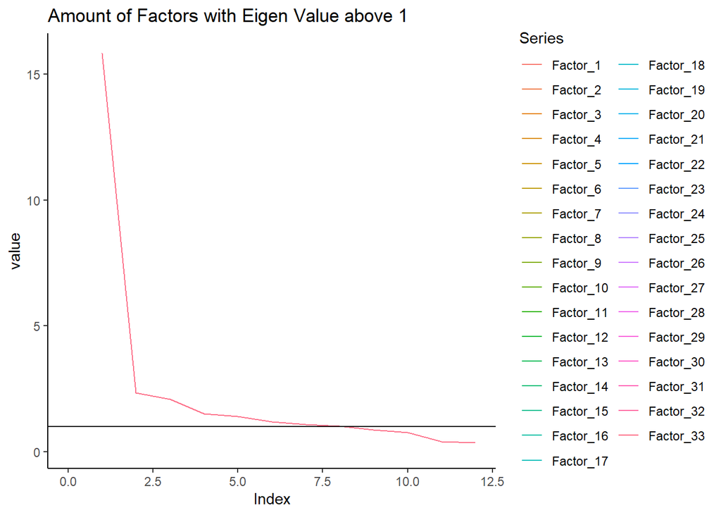

```r
#calculate the eigen values with best number of factors
best_eigen_melt <- melt(best_eigen_pc ,  id.vars = "Index", variable.name = "Series")
best_eigen_plot <- ggplot(best_eigen_melt, aes(Index, value))+
  geom_line(aes(color = Series))+
  xlim(0,12)+
  geom_hline(yintercept=1)+
  ggtitle("Amount of Factors with Eigen Value above 1")+
  labs(xlab="Amount of Factors", ylab = "Eigen Value")+
  theme_classic()
best_eigen_plot
```

```r
#they all produce 8 groups. Eigen values are the same for every group. with or without qd4 and qd23
```

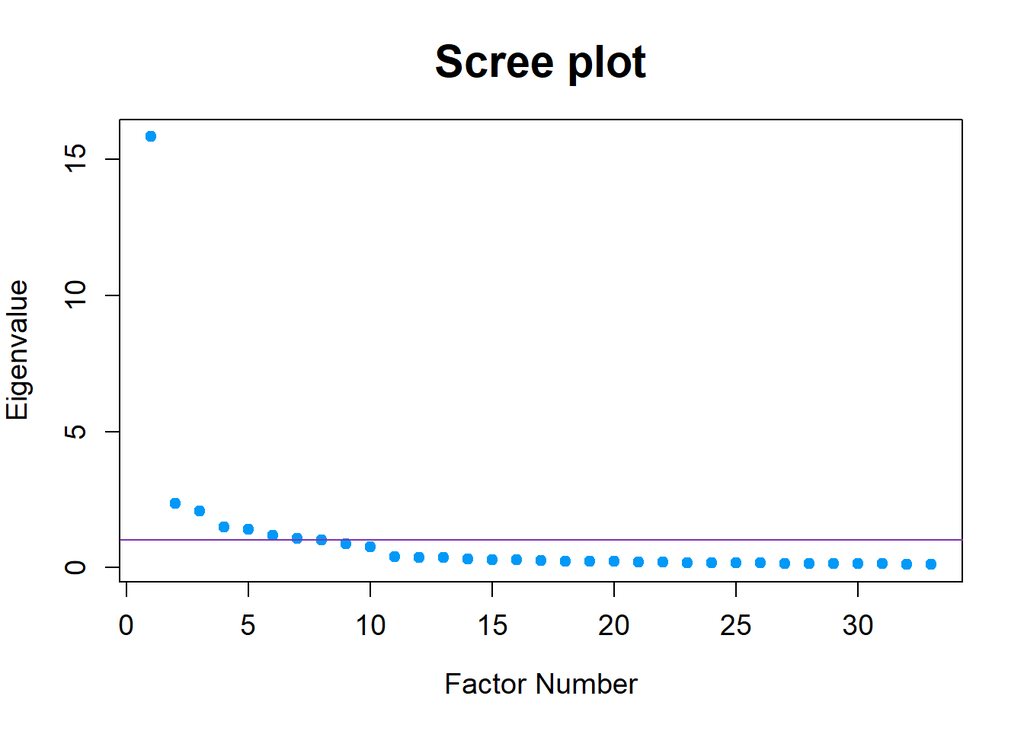

```
## integer(0)
```

```r
#calculate the eigen values with best number of factors
cd_PC1 <- psych::principal(cel_data_quests, nfactors = 8, rotate="varimax", scores=TRUE)

#display Scree-plot
plot(cd_PC1$values,xlab="Factor Number",
     ylab="Eigenvalue",
     main="Scree plot",
     cex.lab=1.2,
     cex.axis=1.2,
     cex.main=1.8,
     col = "#0099F8",
     pch = 19) +abline(h=1, col = "#7F35B2")
```

```r
#calculate total variance using PAF with nfactors = 8
EigenValue <- cd_PC1$values
Variance <- EigenValue / ncol(cel_data_quests) * 100
SumVariance <- cumsum(EigenValue / ncol(cel_data_quests))
Total_Variance_Explained <- cbind(EigenValue = EigenValue[EigenValue>0],
                                  Variance = Variance[EigenValue>0],
                                  Total_Variance = SumVariance[EigenValue>0])
#display table
Total_Variance_Explained |>
  kable() |>
  kable_minimal()
```

| EigenValue | Variance | Total_Variance |
| --- | --- | --- |
| 15.8424645 | 48.0074681 | 0.4800747 |
| 2.3479931 | 7.1151305 | 0.5512260 |
| 2.0859016 | 6.3209138 | 0.6144351 |
| 1.4997060 | 4.5445638 | 0.6598808 |
| 1.4033246 | 4.2524987 | 0.7024057 |
| 1.1898355 | 3.6055621 | 0.7384614 |
| 1.0750020 | 3.2575817 | 0.7710372 |
| 1.0062911 | 3.0493669 | 0.8015309 |
| 0.8599154 | 2.6058042 | 0.8275889 |
| 0.7558600 | 2.2904849 | 0.8504937 |
| 0.4040664 | 1.2244438 | 0.8627382 |
| 0.3650604 | 1.1062436 | 0.8738006 |
| 0.3544695 | 1.0741500 | 0.8845421 |
| 0.2976911 | 0.9020943 | 0.8935631 |
| 0.2852767 | 0.8644748 | 0.9022078 |
| 0.2787420 | 0.8446726 | 0.9106545 |
| 0.2604348 | 0.7891964 | 0.9185465 |
| 0.2366327 | 0.7170689 | 0.9257172 |
| 0.2300409 | 0.6970935 | 0.9326881 |
| 0.2161357 | 0.6549567 | 0.9392377 |
| 0.2029174 | 0.6149013 | 0.9453867 |
| 0.1947445 | 0.5901349 | 0.9512881 |
| 0.1817628 | 0.5507965 | 0.9567960 |
| 0.1703433 | 0.5161918 | 0.9619579 |
| 0.1664408 | 0.5043661 | 0.9670016 |
| 0.1558947 | 0.4724081 | 0.9717257 |
| 0.1528143 | 0.4630737 | 0.9763564 |
| 0.1481824 | 0.4490374 | 0.9808468 |
| 0.1405732 | 0.4259793 | 0.9851066 |
| 0.1361523 | 0.4125828 | 0.9892324 |
| 0.1303892 | 0.3951187 | 0.9931836 |
| 0.1163707 | 0.3526384 | 0.9967100 |
| 0.1085705 | 0.3290016 | 1.0000000 |

```r
#plot communalities
paf1_communalities <- data.frame(sort(cd_PC1$communality))
paf1_communalities |>
  kable() |>
  kable_minimal()
```

|  | sort.cd_PC1.communality. |
| --- | --- |
| qd23 | 0.5415878 |
| qd28 | 0.6002909 |
| qd26 | 0.6185755 |
| qd31 | 0.6739616 |
| qd4 | 0.6935527 |
| qd16 | 0.7220532 |
| qd8 | 0.7470242 |
| qd18 | 0.7480937 |
| qd5 | 0.7754771 |
| qd17 | 0.8013673 |
| qd32 | 0.8037999 |
| qd11 | 0.8084697 |
| qd12 | 0.8096602 |
| qd15 | 0.8152734 |
| qd30 | 0.8191505 |
| qd21 | 0.8222111 |
| qd3 | 0.8316364 |
| qd2 | 0.8322741 |
| qd25 | 0.8400361 |
| qd13 | 0.8403376 |
| qd33 | 0.8473262 |
| qd7 | 0.8475292 |
| qd6 | 0.8518275 |
| qd10 | 0.8674395 |
| qd29 | 0.8693089 |
| qd19 | 0.8711939 |
| qd9 | 0.8723112 |
| qd20 | 0.8723638 |
| qd27 | 0.8736279 |
| qd14 | 0.8783966 |
| qd1 | 0.8788204 |
| qd22 | 0.8804932 |
| qd24 | 0.8950466 |

```r
#qd23 has the lowest communality but it is not terribly far away from the other values
#qd4 is low but not the worst


pc_loads <- print(cd_PC1$loadings, cutoff=0.4, sort=TRUE)
```

```
##
## Loadings:
##      RC2    RC1    RC7    RC5    RC4    RC8    RC3    RC6
## qd9   0.850
## qd14  0.869
## qd19  0.851
## qd21  0.823
## qd24  0.869
## qd2          0.760
## qd5          0.704
## qd7          0.758
## qd12         0.743
## qd16         0.707
## qd15                0.773
## qd17                0.745
## qd26                0.586
## qd28                0.578
## qd31                0.683
## qd32                0.726
## qd1                        0.818
## qd10                       0.779
## qd20                       0.803
## qd27                       0.779
## qd3                               0.804
## qd11                              0.809
## qd13                              0.767
## qd30                              0.718
## qd6                                      0.752
## qd8                                      0.623
## qd18                                     0.698
## qd25                                     0.793
## qd22                                            0.844
## qd29                                            0.828
## qd33                                            0.831
## qd4                                                    0.811
## qd23                                                   0.672
##
##                  RC2   RC1   RC7   RC5   RC4   RC8   RC3   RC6
## SS loadings    4.664 3.963 3.899 3.543 3.321 2.942 2.882 1.237
## Proportion Var 0.141 0.120 0.118 0.107 0.101 0.089 0.087 0.037
## Cumulative Var 0.141 0.261 0.380 0.487 0.588 0.677 0.764 0.802
```

In this case , the loadings match the questions as follow:

- Questions 2, 5, 7, 12, 16 are regarding **Performance**
- Questions 9, 14, 19, 21, 24 are regarding **Serviceability**
- Questions 22, 29, 33 are regarding **Reliability**
- Questions 3, 11, 13, 30 are regarding **Ease of use**
- Questions 1, 10, 20, 27 are regarding **Aesthetics**
- Questions 4 and 23 are regarding **Prestige**
- Questions 15, 17, 26, 28, 31, 32 are regarding **Durability**
- Questions 6, 8, 18, 25 are regarding **Features**

**Click here to detailed groupings**

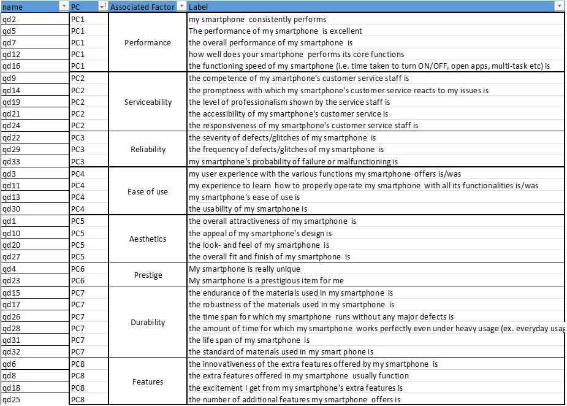

Groupings as per PCA analysis. Source: own creation

```r
#calculate model without questions qd4 and qd23
cd_PC_minus4_23 <- psych::principal(cel_data_quests[,-c(4,23)], nfactors = 8, rotate="varimax", scores=TRUE)

#show loadings
pc_loads <- print(cd_PC_minus4_23$loadings, cutoff=0.4, sort=TRUE)
```

```
##
## Loadings:
##      RC2   RC1   RC5   RC4   RC7   RC3   RC6   RC8
## qd9  0.850
## qd14 0.868
## qd19 0.851
## qd21 0.822
## qd24 0.869
## qd2        0.755
## qd5        0.706
## qd7        0.760
## qd12       0.750
## qd16       0.709
## qd1              0.824
## qd10             0.781
## qd20             0.805
## qd27             0.776
## qd3                    0.805
## qd11                   0.816
## qd13                   0.768
## qd30                   0.717
## qd6                          0.761
## qd8                          0.628
## qd18                         0.713
## qd25                         0.806
## qd22                               0.849
## qd29                               0.834
## qd33                               0.836
## qd15                                     0.791
## qd17                                     0.781
## qd32                                     0.764
## qd26                                           0.727
## qd28                                           0.774
## qd31                                           0.738
##
##                  RC2   RC1   RC5   RC4   RC7   RC3   RC6   RC8
## SS loadings    4.655 3.902 3.495 3.316 3.005 2.842 2.494 2.330
## Proportion Var 0.150 0.126 0.113 0.107 0.097 0.092 0.080 0.075
## Cumulative Var 0.150 0.276 0.389 0.496 0.593 0.684 0.765 0.840
```

Finally, in this scenario, the loadings match the questions as follow:

**Click here to detailed groupings**

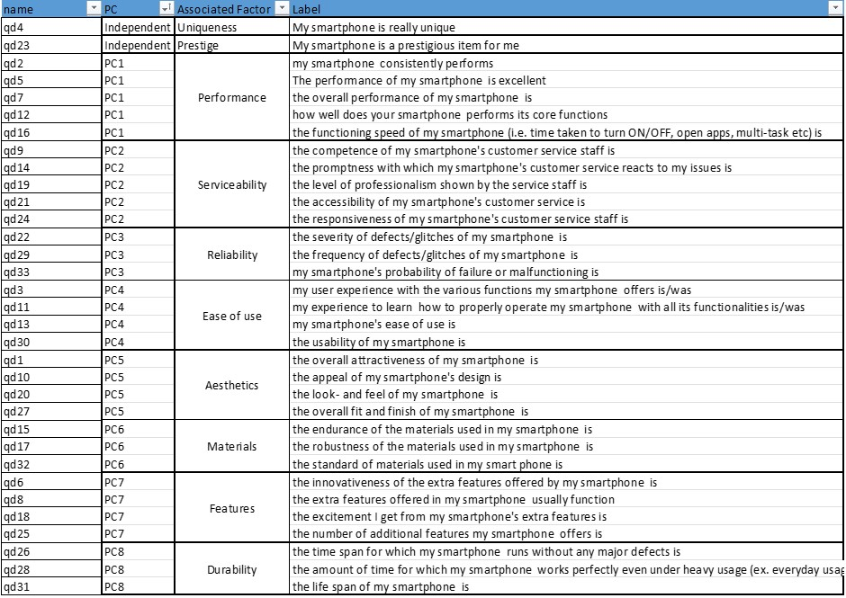

Groupings as per PCA analysis without questions qd4 and qd23. Source: own creation

# 4 Oblique Rotation

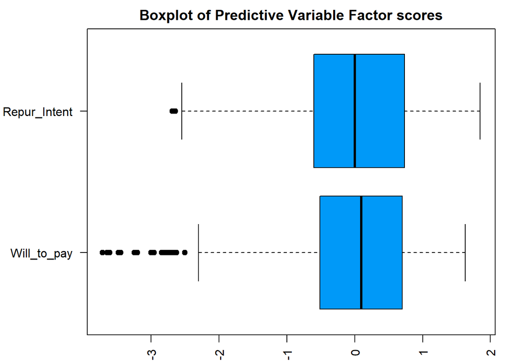

```r
#create table for new prediction factors
cd_oblique <- na.omit(cel_data[, c(43:45, 51:52)])

#run all models using oblique rotation
cd_oblq1 <- psych::principal(cel_data_quests, rotate="promax",nfactors=8, scores=TRUE)
cd_oblq2 <- psych::principal(cel_data_quests[,-c(4,23)], rotate="promax",nfactors=8, scores=TRUE)
cd_oblq3 <- psych::principal(cd_oblique, rotate="promax",nfactors=2, scores=TRUE)

#create Summary table for prediction
pred_table <- data.frame(cd_oblq1$scores)
pred_table <- cbind(pred_table,cd_oblq3$scores)
colnames(pred_table)[1:10]=c("Serviceability",
                          "Performance",
                          "Durability",
                          "Aesthetics",
                          "Ease_of_use",
                          "Features",
                          "Reliability",
                          "Prestige",
                          "Will_to_pay",
                          "Repur_Intent")

pred_table2 <- data.frame(cd_oblq2$scores)
pred_table2 <- cbind(pred_table2,cd_oblq3$scores)
pred_table2 <- cbind(pred_table2,cel_data_quests[,c(4,23)])
colnames(pred_table2)[1:10]=c("Serviceability",
                          "Performance",
                          "Aesthetics",
                          "Ease_of_use",
                          "Features",
                          "Reliability",
                          "Materials",
                          "Durability",
                          "Will_to_pay",
                          "Repur_Intent",
                          "Prestige",
                          "Uniqueness")

#box plots to see the mean of the predictive variables
par(mar = c(2,6,2,1))
boxplot(pred_table[,9:10],
        horizontal = T,
        main = "Boxplot of Predictive Variable Factor scores",
        col = "#0099F8",
        las = 2,
        pch = 19)
```

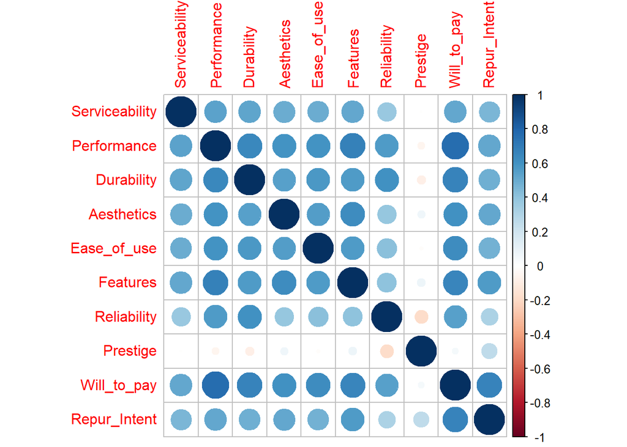

```r
pred_corr_matrix <- cor(pred_table)
corrplot(as.matrix(pred_corr_matrix))
```

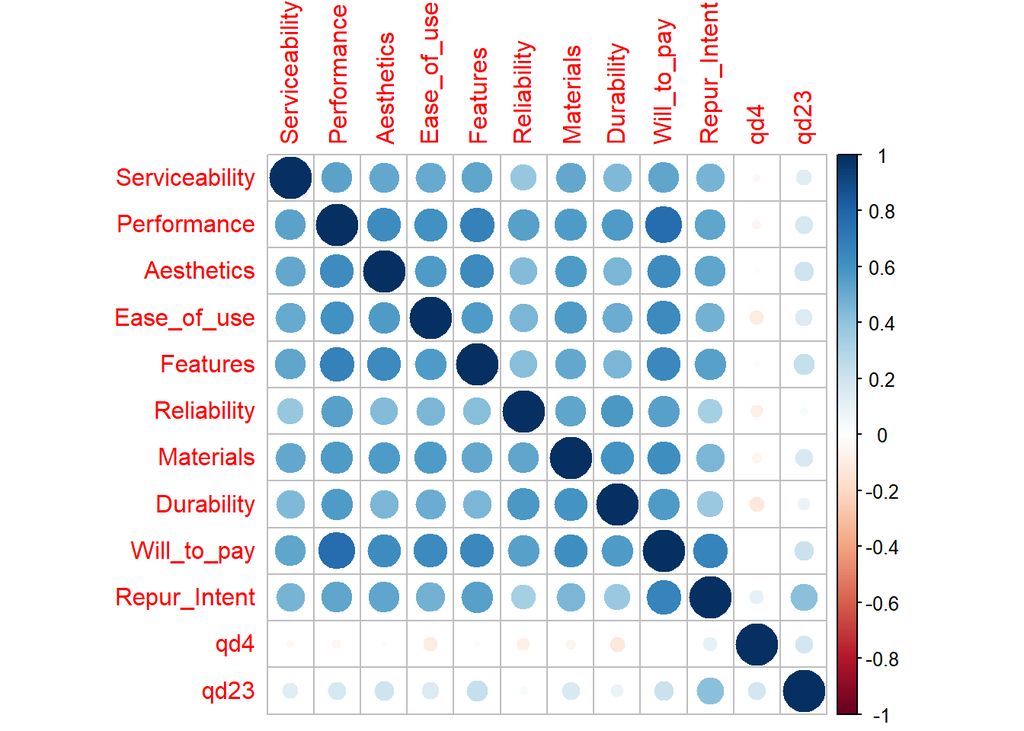

```r
pred_corr_matrix <- cor(pred_table2)
corrplot(as.matrix(pred_corr_matrix))
```

# 5 Regression Analysis

```r
#Standardize the variables
pred_table_scl <- as.data.table(scale(pred_table))
pred_table2_scl <- as.data.table(scale(pred_table2))

#predict Willingness_to_pay according to the 2 proposed models
wtp_model <- lm(Will_to_pay ~ Serviceability + Performance + Durability + Aesthetics + Ease_of_use + Features + Reliability + Prestige, data = pred_table_scl)

wtp_model2 <- lm(Will_to_pay ~ Serviceability + Performance + Durability + Aesthetics + Ease_of_use + Features + Reliability + qd4 + qd23, data = pred_table2_scl)

summary(wtp_model)
```

```
##
## Call:
## lm(formula = Will_to_pay ~ Serviceability + Performance + Durability +
##     Aesthetics + Ease_of_use + Features + Reliability + Prestige,
##     data = pred_table_scl)
##
## Residuals:
##     Min      1Q  Median      3Q     Max
## -3.0945 -0.2805  0.0604  0.3478  1.8500
##
## Coefficients:
##                 Estimate Std. Error t value Pr(>|t|)
## (Intercept)    1.657e-16  1.823e-02   0.000  1.00000
## Serviceability 2.378e-02  2.339e-02   1.017  0.30947
## Performance    3.928e-01  2.976e-02  13.196  < 2e-16 ***
## Durability     1.539e-01  2.802e-02   5.492 5.09e-08 ***
## Aesthetics     8.030e-02  2.566e-02   3.129  0.00181 **
## Ease_of_use    1.450e-01  2.518e-02   5.758 1.15e-08 ***
## Features       1.100e-01  2.770e-02   3.972 7.66e-05 ***
## Reliability    9.818e-02  2.425e-02   4.049 5.55e-05 ***
## Prestige       8.584e-02  1.895e-02   4.529 6.68e-06 ***
## ---
## Signif. codes:  0 '***' 0.001 '**' 0.01 '*' 0.05 '.' 0.1 ' ' 1
##
## Residual standard error: 0.5663 on 956 degrees of freedom
## Multiple R-squared:  0.682,  Adjusted R-squared:  0.6793
## F-statistic: 256.3 on 8 and 956 DF,  p-value: < 2.2e-16
```

```r
summary(wtp_model2)
```

```
##
## Call:
## lm(formula = Will_to_pay ~ Serviceability + Performance + Durability +
##     Aesthetics + Ease_of_use + Features + Reliability + qd4 +
##     qd23, data = pred_table2_scl)
##
## Residuals:
##      Min       1Q   Median       3Q      Max
## -3.04238 -0.28863  0.05469  0.35813  1.93078
##
## Coefficients:
##                 Estimate Std. Error t value Pr(>|t|)
## (Intercept)    1.757e-16  1.840e-02   0.000 1.000000
## Serviceability 3.559e-02  2.359e-02   1.508 0.131817
## Performance    3.874e-01  2.972e-02  13.035  < 2e-16 ***
## Durability     9.627e-02  2.489e-02   3.868 0.000117 ***
## Aesthetics     9.506e-02  2.652e-02   3.585 0.000354 ***
## Ease_of_use    1.643e-01  2.562e-02   6.413 2.25e-10 ***
## Features       1.178e-01  2.778e-02   4.241 2.44e-05 ***
## Reliability    1.076e-01  2.410e-02   4.465 8.96e-06 ***
## qd4            6.336e-02  1.899e-02   3.335 0.000884 ***
## qd23           4.056e-02  1.945e-02   2.085 0.037296 *
## ---
## Signif. codes:  0 '***' 0.001 '**' 0.01 '*' 0.05 '.' 0.1 ' ' 1
##
## Residual standard error: 0.5716 on 955 degrees of freedom
## Multiple R-squared:  0.6763, Adjusted R-squared:  0.6732
## F-statistic: 221.7 on 9 and 955 DF,  p-value: < 2.2e-16
```

```r
#predict Repurchase_Intention according to the 2 proposed models
ri_model <- lm(Repur_Intent ~ Serviceability +Performance + Durability + Aesthetics + Ease_of_use + Features + Reliability + Prestige, data = pred_table_scl)

ri_model2 <- lm(Repur_Intent ~ Serviceability +Performance + Durability + Aesthetics + Ease_of_use + Features + Reliability +qd4 + qd23, data = pred_table2_scl)

summary(ri_model)
```

```
##
## Call:
## lm(formula = Repur_Intent ~ Serviceability + Performance + Durability +
##     Aesthetics + Ease_of_use + Features + Reliability + Prestige,
##     data = pred_table_scl)
##
## Residuals:
##      Min       1Q   Median       3Q      Max
## -2.87590 -0.43105  0.03637  0.48047  2.21401
##
## Coefficients:
##                  Estimate Std. Error t value Pr(>|t|)
## (Intercept)    -1.685e-16  2.365e-02   0.000 1.000000
## Serviceability  1.117e-01  3.035e-02   3.682 0.000245 ***
## Performance     1.253e-01  3.862e-02   3.245 0.001215 **
## Durability      1.263e-01  3.636e-02   3.473 0.000538 ***
## Aesthetics      1.152e-01  3.330e-02   3.460 0.000564 ***
## Ease_of_use     1.012e-01  3.267e-02   3.098 0.002005 **
## Features        1.982e-01  3.594e-02   5.516 4.47e-08 ***
## Reliability     8.094e-03  3.146e-02   0.257 0.797006
## Prestige        2.564e-01  2.459e-02  10.427  < 2e-16 ***
## ---
## Signif. codes:  0 '***' 0.001 '**' 0.01 '*' 0.05 '.' 0.1 ' ' 1
##
## Residual standard error: 0.7347 on 956 degrees of freedom
## Multiple R-squared:  0.4647, Adjusted R-squared:  0.4602
## F-statistic: 103.7 on 8 and 956 DF,  p-value: < 2.2e-16
```

```r
summary(ri_model2)
```

```
##
## Call:
## lm(formula = Repur_Intent ~ Serviceability + Performance + Durability +
##     Aesthetics + Ease_of_use + Features + Reliability + qd4 +
##     qd23, data = pred_table2_scl)
##
## Residuals:
##      Min       1Q   Median       3Q      Max
## -2.84449 -0.42935  0.02892  0.45443  2.25447
##
## Coefficients:
##                  Estimate Std. Error t value Pr(>|t|)
## (Intercept)    -1.949e-16  2.341e-02   0.000 1.000000
## Serviceability  1.319e-01  3.002e-02   4.393 1.24e-05 ***
## Performance     1.172e-01  3.781e-02   3.099 0.002001 **
## Durability      3.300e-02  3.167e-02   1.042 0.297673
## Aesthetics      1.516e-01  3.374e-02   4.492 7.90e-06 ***
## Ease_of_use     1.056e-01  3.260e-02   3.238 0.001246 **
## Features        1.537e-01  3.535e-02   4.347 1.53e-05 ***
## Reliability     2.225e-02  3.067e-02   0.726 0.468218
## qd4             8.733e-02  2.417e-02   3.613 0.000318 ***
## qd23            2.691e-01  2.475e-02  10.875  < 2e-16 ***
## ---
## Signif. codes:  0 '***' 0.001 '**' 0.01 '*' 0.05 '.' 0.1 ' ' 1
##
## Residual standard error: 0.7274 on 955 degrees of freedom
## Multiple R-squared:  0.4759, Adjusted R-squared:  0.471
## F-statistic: 96.35 on 9 and 955 DF,  p-value: < 2.2e-16
```

```r
#for model with all variables included
pred_table <- cbind(pred_table, cel_data$brandrec)
pred_table_b1 <- pred_table[pred_table[,11] == 1,]
pred_table_b2 <- pred_table[pred_table[,11] == 2,]
pred_table_b3 <- pred_table[pred_table[,11] == 3,]
pred_table_b4 <- pred_table[pred_table[,11] == 4,]
pred_table_b5 <- pred_table[pred_table[,11] == 5,]

#for model excluding qd4 and qd23
pred_table2 <- cbind(pred_table2, cel_data$brandrec)
names(pred_table2)[names(pred_table2) == 'cel_data$brandrec'] <- "brandrec"
pred_table2_b1 <- pred_table2[pred_table2[,13] == 1,]
pred_table2_b2 <- pred_table2[pred_table2[,13] == 2,]
pred_table2_b3 <- pred_table2[pred_table2[,13] == 3,]
pred_table2_b4 <- pred_table2[pred_table2[,13] == 4,]
pred_table2_b5 <- pred_table2[pred_table2[,13] == 5,]
```

```r
#Regressing on the different data sets for WTP
sum_wtp1 <- data.table("Factor" = c(colnames(pred_table[,-c(9:11)])))
for(i in 1:5){
  if(i == 1){
    data_set <- pred_table_b1
  } else if (i == 2){
    data_set <- pred_table_b2
  } else if (i == 3){
    data_set <- pred_table_b3
  } else if (i == 4){
    data_set <- pred_table_b4
  } else {
    data_set <- pred_table_b5
  }

  nam <- paste("wtp_model_b", i, sep="")
  assign(nam, lm(Will_to_pay ~ Serviceability +Performance + Durability + Aesthetics + Ease_of_use + Features + Reliability + Prestige, data = data_set))

  options(scipen=-999999, digits = 2)
  temp_model <- summary(get(nam))
  sum_wtp1 <- sum_wtp1[,paste("brand_",i,sep=""):=temp_model$coefficients[2:9, 4]]
}
rm(temp_model)

print(sum_wtp1)
```

```
##            Factor brand_1 brand_2 brand_3 brand_4 brand_5
## 1: Serviceability 1.1e-01 4.8e-01 2.1e-01 7.1e-01 6.5e-01
## 2:    Performance 3.0e-13 5.7e-12 2.1e-04 6.5e-04 1.2e-03
## 3:     Durability 3.6e-04 2.2e-02 6.1e-02 3.5e-02 7.5e-02
## 4:     Aesthetics 5.7e-06 7.7e-01 6.5e-01 3.4e-01 9.7e-01
## 5:    Ease_of_use 2.6e-04 8.9e-03 2.0e-01 3.9e-04 7.8e-01
## 6:       Features 5.2e-03 6.1e-02 4.8e-02 6.2e-01 1.4e-01
## 7:    Reliability 4.4e-03 2.7e-02 1.1e-02 7.9e-01 3.0e-01
## 8:       Prestige 1.7e-03 3.1e-03 1.2e-01 2.1e-01 2.9e-01
```

```r
#Regressing on the different data sets for RI
sum_ri1 <- data.table("Factor" = c(colnames(pred_table[,-c(9:11)])))
for(i in 1:5){
  if(i == 1){
    data_set <- pred_table_b1
  } else if (i == 2){
    data_set <- pred_table_b2
  } else if (i == 3){
    data_set <- pred_table_b3
  } else if (i == 4){
    data_set <- pred_table_b4
  } else {
    data_set <- pred_table_b5
  }

  nam <- paste("ri_model_b", i, sep="")
  assign(nam, lm(Repur_Intent ~ Serviceability +Performance + Durability + Aesthetics + Ease_of_use + Features + Reliability + Prestige, data = data_set))

  options(scipen=-999999, digits = 2)
  temp_model <- summary(get(nam))
  sum_ri1 <- sum_ri1[,paste("brand_",i,sep=""):=temp_model$coefficients[2:9, 4]]
}
rm(temp_model)
print(sum_ri1)
```

```
##            Factor brand_1 brand_2 brand_3 brand_4 brand_5
## 1: Serviceability 1.2e-04 2.7e-01 2.0e-01 7.0e-02 1.8e-02
## 2:    Performance 3.9e-01 1.2e-02 6.5e-01 8.4e-01 9.2e-04
## 3:     Durability 4.0e-04 3.6e-02 9.9e-01 8.0e-02 8.6e-01
## 4:     Aesthetics 7.3e-04 2.4e-01 2.0e-01 9.7e-01 2.9e-01
## 5:    Ease_of_use 1.3e-03 3.2e-01 7.1e-01 9.5e-02 1.1e-02
## 6:       Features 2.8e-04 9.9e-04 6.8e-02 4.9e-01 3.6e-01
## 7:    Reliability 7.5e-01 3.8e-01 3.7e-01 3.6e-01 8.7e-01
## 8:       Prestige 2.3e-11 3.0e-08 9.6e-04 4.4e-03 1.2e-04
```

```r
#Regressing on the different data sets for WTP
sum_wtp2 <- data.table("Factor" = c(colnames(pred_table2[,-c(9:10,13)])))
for(i in 1:5){
  if(i == 1){
    data_set <- pred_table2_b1
  } else if (i == 2){
    data_set <- pred_table2_b2
  } else if (i == 3){
    data_set <- pred_table2_b3
  } else if (i == 4){
    data_set <- pred_table2_b4
  } else {
    data_set <- pred_table2_b5
  }

  nam <- paste("wtp_model2_b", i, sep="")
  assign(nam, lm(Will_to_pay ~ Serviceability + Performance + Durability + Aesthetics + Ease_of_use + Features + Reliability + Materials + qd4 + qd23, data = data_set))

  options(scipen=-999999, digits = 2)
  temp_model <- summary(get(nam))
  sum_wtp2 <- sum_wtp2[,paste("brand_",i,sep=""):=temp_model$coefficients[2:11, 4]]
}
rm(temp_model)

print(sum_wtp2)
```

```
##             Factor brand_1 brand_2 brand_3 brand_4 brand_5
##  1: Serviceability 1.3e-01 4.8e-01 1.9e-01 9.3e-01 9.0e-01
##  2:    Performance 2.0e-13 4.3e-11 4.1e-04 7.1e-04 2.4e-02
##  3:     Aesthetics 4.1e-01 1.1e-01 6.1e-01 1.3e-01 6.8e-04
##  4:    Ease_of_use 2.9e-05 7.2e-01 5.5e-01 2.4e-01 3.8e-01
##  5:       Features 4.8e-04 1.1e-02 1.9e-01 1.9e-03 3.6e-01
##  6:    Reliability 2.9e-03 6.4e-02 6.6e-02 3.6e-01 1.1e-01
##  7:      Materials 4.7e-03 5.2e-02 3.1e-02 5.9e-01 9.7e-01
##  8:     Durability 9.7e-04 1.2e-01 5.1e-02 3.0e-01 4.3e-01
##  9:            qd4 2.2e-02 4.5e-02 3.0e-01 5.2e-02 1.4e-01
## 10:           qd23 3.5e-01 9.9e-02 8.4e-01 6.1e-01 3.4e-01
```

```r
#Regressing on the different data sets for RI
sum_ri2 <- data.table("Factor" = c(colnames(pred_table2[,-c(9:10,13)])))
for(i in 1:5){
  if(i == 1){
    data_set <- pred_table2_b1
  } else if (i == 2){
    data_set <- pred_table2_b2
  } else if (i == 3){
    data_set <- pred_table2_b3
  } else if (i == 4){
    data_set <- pred_table2_b4
  } else {
    data_set <- pred_table2_b5
  }

  nam <- paste("ri_model2_b", i, sep="")
  assign(nam, lm(Repur_Intent ~ Serviceability + Performance + Durability + Aesthetics + Ease_of_use + Features + Reliability + Materials + qd4 + qd23, data = data_set))

  options(scipen=-999999, digits = 2)
  temp_model <- summary(get(nam))
  sum_ri2 <- sum_ri2[,paste("brand_",i,sep=""):=temp_model$coefficients[2:11, 4]]
}
rm(temp_model)

print(sum_ri2)
```

```
##             Factor brand_1 brand_2 brand_3 brand_4 brand_5
##  1: Serviceability 4.7e-05 4.4e-01 2.4e-01 6.8e-02 1.1e-02
##  2:    Performance 4.2e-01 2.4e-02 6.0e-01 8.3e-01 9.3e-03
##  3:     Aesthetics 6.2e-01 8.2e-02 5.3e-01 1.0e+00 6.4e-01
##  4:    Ease_of_use 1.2e-04 7.5e-02 1.8e-01 9.0e-01 1.6e-01
##  5:       Features 1.5e-03 2.2e-01 7.6e-01 1.3e-01 1.3e-02
##  6:    Reliability 5.9e-03 2.3e-02 7.0e-02 6.0e-01 4.4e-01
##  7:      Materials 6.2e-01 3.2e-01 3.5e-01 3.5e-01 7.1e-01
##  8:     Durability 7.3e-02 7.3e-01 9.1e-01 1.4e-01 8.7e-01
##  9:            qd4 4.7e-02 5.0e-02 5.4e-02 1.6e-01 3.0e-02
## 10:           qd23 2.7e-12 2.4e-12 4.8e-02 2.1e-02 3.3e-03
```